# Data Processing and Cleaning

## Packages

```python
import pandas as pd
import re
from bs4 import BeautifulSoup
import requests
import seaborn as sns
import numpy as np
import matplotlib.pyplot as plt
%matplotlib inline
from fuzzywuzzy import fuzz
from fuzzywuzzy import process
```

## Reading in the csv

```python
S1 = pd.read_csv('Disasters.csv') #reads the csv as S1
S2 = pd.read_csv('Disasters_Recent.csv')
country = pd.read_csv('Country_info.csv')
```

## Viewing the disaster data

```python
S1.head()
```

|  | Unnamed: 0 | Start | End | Country | Location | Type | Sub_Type | Names | Killed | Affected | International support |
| --- | --- | --- | --- | --- | --- | --- | --- | --- | --- | --- | --- |
| 0 | 0 | 1965-06-01 | 1965-06-01 | Japan | NaN | storm | tropical cyclone | Dinah | 61.0 | 30000.0 | 1934.944 |
| 1 | 1 | 2004-09-01 | 2004-09-01 | Grenada | NaN | storm | tropical cyclone | Ivan | 39.0 | 60000.0 | 1090.830 |
| 2 | 2 | 1995-03-01 | 1995-03-01 | Russia | Kalmoukie:Daghestan (Mer ... | transport accident | water | NaN | 52.0 | NaN | NaN |
| 3 | 3 | 1983-02-01 | 1983-02-01 | Cuba | Santiago de Cuba:Pinar d ... | flood | NaN | NaN | 15.0 | 164575.0 | 905.275 |
| 4 | 4 | 1996-07-01 | 1996-07-01 | Russia | Volgorgrad | industrial accident | gas leak | Oil refinery | NaN | NaN | NaN |

## Disaster data properties

#### Data types

```python
S1.dtypes, S1.shape #gets the rows and column number of the data, and the data types
```

```
(Unnamed: 0                 int64
 Start                     object
 End                       object
 Country                   object
 Location                  object
 Type                      object
 Sub_Type                  object
 Names                     object
 Killed                   float64
 Affected                 float64
 International support    float64
 dtype: object, (13694, 11))
```

#### Uniqueness of each columns

```python
uniqueness = {}
for i in S1.columns[0:6]:
    uniqueness[i] = len(set(S1[str(i)])) #calculates the number of uniques for certain columns
uniqueness
```

```
{'Country': 215,
 'End': 1012,
 'Location': 10227,
 'Start': 1006,
 'Type': 15,
 'Unnamed: 0': 13694}
```

#### Statistical summaries of all number columns

```python
S1.describe() #statistical summary of the numerical columns
```

|  | Unnamed: 0 | Killed | Affected | International support |
| --- | --- | --- | --- | --- |
| count | 13694.000000 | 1.109800e+04 | 8.517000e+03 | 6838.000000 |
| mean | 6846.500000 | 9.168695e+02 | 4.535407e+05 | 1014.796600 |
| std | 3953.261628 | 4.059689e+04 | 5.962458e+06 | 446.388995 |
| min | 0.000000 | 1.000000e+00 | 1.000000e+00 | 0.000000 |
| 25% | 3423.250000 | 1.200000e+01 | 5.100000e+01 | 696.652000 |
| 50% | 6846.500000 | 2.400000e+01 | 7.950000e+02 | 1076.298500 |
| 75% | 10269.750000 | 5.500000e+01 | 1.500000e+04 | 1324.180750 |
| max | 13693.000000 | 3.700000e+06 | 3.000000e+08 | 2801.093000 |

#### Missing values

```python
S1.isnull().sum() / len(S1) * 100 #calculcates the percentage of missing values
```

```
Unnamed: 0                0.000000
Start                     0.000000
End                       0.000000
Country                   0.000000
Location                 12.224332
Type                      0.000000
Sub_Type                 12.998393
Names                    67.547831
Killed                   18.957208
Affected                 37.804878
International support    50.065722
dtype: float64
```

#### Summary

This distaster data contains 11 variables, in which one of them is a representation of the index of reach rows, hence this column can be removed. There are 13694 records of disaster in total. This dataset had already been formated and cleaned to an appropriate level.

[output not shown]

Some columns such as Location, Sub_Type, Names and all numerical columns have missing values, where Names has the highest count at 67%.

#### Removing the first column to maintain uniqueness

```python
del S1["Unnamed: 0"] #removes column
```

## Viewing the recent disaster data

```python
S2.head()
```

|  | year | disaster type | Country iso; Country name | disaster group | disaster subgroup | disaster subtype | continent | region | occurrence | Total deaths | Affected | Injured | Homeless | Total affected | Total damage | International support | Unnamed: 16 |
| --- | --- | --- | --- | --- | --- | --- | --- | --- | --- | --- | --- | --- | --- | --- | --- | --- | --- |
| 0 | 2000 | Drought | AFG | Afghanistan | Natural | Climatological | Drought | Asia | Southern Asia | 1 | 37 | 2580000 | 0 | 0 | 2580000 | 50 | 122245.87 |
| 1 | 2000 | Drought | ARM | Armenia | Natural | Climatological | Drought | Asia | Western Asia | 1 | 0 | 297000 | 0 | 0 | 297000 | 100000 | 5400.00 |
| 2 | 2000 | Drought | AZE | Azerbaijan | Natural | Climatological | Drought | Asia | Western Asia | 1 | 0 | 0 | 0 | 0 | 0 | 100000 | 0.00 |
| 3 | 2000 | Drought | BOL | Bolivia (Plurinational State of) | Natural | Climatological | Drought | Americas | South America | 1 | 0 | 20000 | 0 | 0 | 20000 | 0 | 0.00 |
| 4 | 2000 | Drought | BIH | Bosnia and Herzegovina | Natural | Climatological | Drought | Europe | Southern Europe | 1 | 0 | 0 | 0 | 0 | 0 | 158000 | 0.00 |

```python
S2.dtypes, S2.shape
```

```
(year                           int64
 disaster type                 object
 Country iso; Country name     object
 disaster group                object
 disaster subgroup             object
 disaster subtype              object
 continent                     object
 region                        object
 occurrence                    object
 Total deaths                   int64
 Affected                       int64
 Injured                        int64
 Homeless                       int64
 Total affected                 int64
 Total damage                   int64
 International support          int64
 Unnamed: 16                  float64
 dtype: object, (4503, 17))
```

```python
uniqueness = {}
for i in S2.columns[0:8]:
    uniqueness[i] = len(set(S2[str(i)]))
uniqueness
```

```
{'Country iso; Country name': 208,
 'continent': 25,
 'disaster group': 208,
 'disaster subgroup': 1,
 'disaster subtype': 6,
 'disaster type': 13,
 'region': 5,
 'year': 16}
```

```python
S2.describe()
```

|  | year | Total deaths | Affected | Injured | Homeless | Total affected | Total damage | International support | Unnamed: 16 |
| --- | --- | --- | --- | --- | --- | --- | --- | --- | --- |
| count | 4503.000000 | 4503.000000 | 4503.000000 | 4.503000e+03 | 4.503000e+03 | 4.503000e+03 | 4.503000e+03 | 4.503000e+03 | 4.503000e+03 |
| mean | 2006.862980 | 1.487453 | 283.107928 | 7.008994e+05 | 9.885121e+02 | 7.934043e+03 | 7.098220e+05 | 4.060303e+05 | 3.278355e+05 |
| std | 4.590094 | 1.220024 | 5098.935313 | 6.991750e+06 | 2.853263e+04 | 1.135478e+05 | 7.003915e+06 | 4.557971e+06 | 3.890726e+05 |
| min | 2000.000000 | 1.000000 | 0.000000 | 0.000000e+00 | 0.000000e+00 | 0.000000e+00 | 0.000000e+00 | 0.000000e+00 | 0.000000e+00 |
| 25% | 2003.000000 | 1.000000 | 0.000000 | 0.000000e+00 | 0.000000e+00 | 0.000000e+00 | 8.350000e+01 | 0.000000e+00 | 0.000000e+00 |
| 50% | 2007.000000 | 1.000000 | 7.000000 | 1.300000e+03 | 0.000000e+00 | 0.000000e+00 | 2.272000e+03 | 0.000000e+00 | 1.957373e+05 |
| 75% | 2011.000000 | 2.000000 | 34.000000 | 2.677900e+04 | 4.000000e+00 | 0.000000e+00 | 3.210000e+04 | 5.136500e+03 | 5.168688e+05 |
| max | 2015.000000 | 17.000000 | 222570.000000 | 3.000000e+08 | 1.800000e+06 | 5.000000e+06 | 3.000000e+08 | 2.100000e+08 | 3.044472e+06 |

#### Summary

The recent distaster data contains all distaster from the year 2000 to 2015, it is the extension to the previous disaster data, however the schema is in a different format.

| Variable | Type | Comments |
| --- | --- | --- |
| Year | int | 16 different types of dates in YYYY format, ranged from 2000 to 2015 |
| disaster type | object | 13 different types of disasters |
| Country iso; Country name | object | 208 different types iso |
| disaster group | object | 208 different types of groups of disasters |
| disaster subgroup | object | only 1 type of disaster subgroup |
| disaster subtype | object | 6 different types of disaster subtypes |
| continent | object | 25 types of continent, disasters that affected large area |
| region | object | 5 different geographical regions that were affected |
| occurrence | object | Number of people affected ranged from 1 to 30 millions |
| Total deaths | int | Number of deaths ranged from 1 to 17 |
| Affected | int | Number of people affected ranged from 0 to 22,2570 |
| Injured | int | People injured ranged from 0 to 300 million |
| Homeless | int | The amount of people who are homeless ranged from 0 to 1.8 million |
| Total affected | int | 0 to 5 million are the ranges for total affected |
| Total damage | int | cost of damage ranged from 0 to 300 million USD |
| International support | int | Support given in money ranged from 0 to 210 million |
| Unamed: 16 | float | This column is annonymous, however it seemed like financial data ranging from 0 to 3 million |

These column names are incorrectly labeled. For example, the number of deaths cannot be from 1 to 17, where in S1 (Killed) it was from 1 to 3.7 millions.

## Checking schema conflicts

### Column Names

The column names in the recent disaster dataset (S2) is incorrectly labeled. It can be seen that according to http://www.emdat.be/classification, which was where the dataset was recieved from, the column that cotains information on the name of the country is meant to be country name, and the column next to it is meant to be disaster group, hence the column name is shifted one column to the right after Country. The semicolon between country iso and country name was not meant to be there.

Some findings:

- Occurence is the number of disaster occurence, hence should be an int not an object, and realistically a disaster cannot occur 30 millions times, hence this column should be Total death instead.
- Theoretically the number of people affected should be greater than the number of people injured
- By shifting the column one to the right, unnamed: 16 becomes international support, and international support becomes total damage

#### Average number of people affected is less than the number of people injured

```python
S2.Affected.mean() > S2.Injured.mean()
```

```
False
```

#### Changing the column names

```python
S2.columns = ['Year', 'disaster type', 'Country iso', 'Country name', 'disaster group', 'disaster subgroup',
                    'disaster subtype', 'continent', 'region', 'occurence', 'Total deaths', 'Affected', 'Injured', 'Homeless', 'Total affected',
                   'Total damage', 'International support'] #renames the column
```

```python
S2.head(3)
```

|  | Year | disaster type | Country iso | Country name | disaster group | disaster subgroup | disaster subtype | continent | region | occurence | Total deaths | Affected | Injured | Homeless | Total affected | Total damage | International support |
| --- | --- | --- | --- | --- | --- | --- | --- | --- | --- | --- | --- | --- | --- | --- | --- | --- | --- |
| 0 | 2000 | Drought | AFG | Afghanistan | Natural | Climatological | Drought | Asia | Southern Asia | 1 | 37 | 2580000 | 0 | 0 | 2580000 | 50 | 122245.87 |
| 1 | 2000 | Drought | ARM | Armenia | Natural | Climatological | Drought | Asia | Western Asia | 1 | 0 | 297000 | 0 | 0 | 297000 | 100000 | 5400.00 |
| 2 | 2000 | Drought | AZE | Azerbaijan | Natural | Climatological | Drought | Asia | Western Asia | 1 | 0 | 0 | 0 | 0 | 0 | 100000 | 0.00 |

#### Naming conflicts between S1 and S2

Although the column names are changed to correctly correspond with each columns, there are still naming conflicts which will create problems with schema integration, such as that Total deaths in S2 is similar to Killed in S1, this will be explored, since Affected and International support are already labeled correctly.

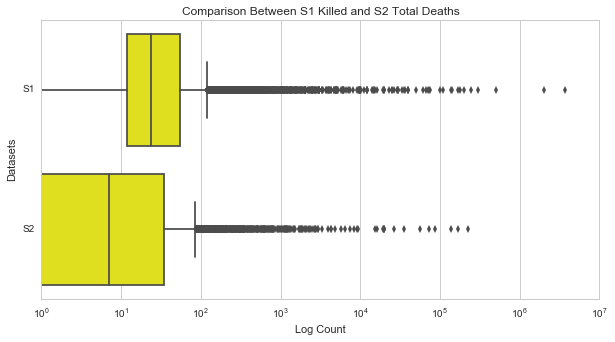

```python
killed_df = pd.DataFrame({'S1':S1.Killed, 'S2': S2['Total deaths']}) #creates dictionary of the two dataset
plt.figure(figsize=(10,5)) #window size of the plot
sns.set_style('whitegrid') # replaces background with white
bxplt = sns.boxplot(killed_df, vert = False, color = 'yellow') #draws boxplot
bxplt.set_xscale('log')
bxplt.set_title('Comparison Between S1 Killed and S2 Total Deaths') #title of the boxplot
bxplt.set_xlabel('Log Count') #lables the x axis
bxplt.set_ylabel('Datasets')#lables the y axis
#bxplt.figure.get_axes()[0].set_xscale('log')
```

#### Webscrapping using beautiful soup

```python
webpage = requests.get('http://www.emdat.be/guidelines') #reads in the site address
bs = BeautifulSoup(webpage.content, 'lxml') #converges in BS
dis_title = bs.findAll('span', {'style': 'font-size:12.0pt'}) #finds all matching tags
```

```python
lists = []
for i in dis_title:
    lists.append(i.get_text()) #recieves the information in text format
newdf = pd.DataFrame({'information': lists}) #creates new DF of the list
#finds all column that has this matching string
search_terms = newdf[newdf.information.str.contains('deaths')].information
search_terms[135], search_terms[137] #prints out the searched terms
```

```
(u'Total deaths', u'deaths + missing people')
```

### Country Names

The recent disaster data shows the country ISO and its corresponding country name. This will be checked witht he provided country dataset which also contains the same ISO and the real country name - BGN_proper.

#### Checking to see all matching ISO between the recent distaster dataset and the country dataset

```python
def matching(data_column, data2_column):
    myList = list(set(data_column) - set(data2_column)) #creates function that column comparison
    return(myList)
```

```python
matching(S2['Country iso'], country.ISO3166A3)
```

```
['SPI', 'SCG']
```

```python
S2[S2['Country iso'] == 'SCG']['Country name'][150], S2[S2['Country iso'] == 'SPI']['Country name'][485]
```

```
('Serbia Montenegro', 'Canary Is')
```

SCG - Serbia Montenegro, SPI - Canary Is, are the only two location names whose country ISO does not match the country dataset's ISO (ISO3166A3). Where as all the others do.

Also good to check for all of the Country names that matches the legitimate country name in the country (BGN_proper) dataset.

#### The use of BGN_proper from country dataset as opposed to other

BGN_proper, U.S. Board on Geographic Names (http://geonames.usgs.gov/), was used instead of ISOen_proper as it resulted in a least number of mismatched when compared with S1. S1 is used as a reference to to correct structure in which S2 must follow to reduce entity resolution/conflic resolution.

```python
country.BGN_proper = country.BGN_proper.str.strip() #removes leading and trailing spaces
```

```python
'ISOen_proper: ', len(matching(S1.Country, country.ISOen_proper)), 'BGN_proper: ', len(matching(S1.Country, country.BGN_proper))
```

```
('ISOen_proper: ', 31, 'BGN_proper: ', 23)
```

#### Checking all matched country name - Value Heterogeneity

43 countries that do not match the country name in the country dataset, this would be replaced by the proper name to maintain value heterogeneity.

```python
matching(S2['Country name'], country.BGN_proper), len(matching(S2['Country name'], country.BGN_proper))
```

```
(['United States of America (the)',
  'Niger (the)',
  'Iran (Islamic Republic of)',
  'Saint Helena, Ascension and Tristan da Cunha',
  'Moldova (the Republic of)',
  "Korea (the Democratic People's Republic of)",
  'Virgin Island (U.S.)',
  'C\xe9te d\x90Ivoire',
  'Micronesia (Federated States of)',
  'Sudan (the)',
  'Cook Islands (the)',
  'Congo (the Democratic Republic of the)',
  'United Kingdom of Great Britain and Northern Irela',
  'Northern Mariana Islands (the)',
  'Marshall Islands (the)',
  'Canary Is',
  'Dominican Republic (the)',
  'Czech Republic (the)',
  'Philippines (the)',
  'Bolivia (Plurinational State of)',
  'Gambia (the)',
  'Macedonia (the former Yugoslav Republic of)',
  "Lao People's Democratic Republic (the)",
  'Cabo Verde',
  'Netherlands (the)',
  'Cayman Islands (the)',
  'Congo (the)',
  'Russian Federation (the)',
  'Palestine, State of',
  'Comoros (the)',
  'Venezuela (Bolivarian Republic of)',
  'Tanzania, United Republic of',
  'Serbia Montenegro',
  'Myanmar',
  'Bahamas (the)',
  'R_union',
  'Viet Nam',
  'Syrian Arab Republic',
  'Turks and Caicos Islands (the)',
  'Korea (the Republic of)',
  'Saint Vincent and the Grenadines',
  'Taiwan (Province of China)',
  'Macao'],
 43)
```

#### Changing the country name in S2 to match BGN_proper

```python
S2['Country name'] = S2['Country name'].str.replace('[()]', '') #removes ( and ) from name
for i in set(S2['Country iso']): #lists all country ISO - uniquely
    if i in set(country.ISO3166A3): #checks if country ISO of recent is in country ISO
        fltr_dstr_rec = S2[S2['Country iso'] == str(i)]['Country name'] #filters by country name  by ISO
        fltr_country = country[country['ISO3166A3'] == str(i)]['BGN_proper'] #filters country name by ISO in country file
        fltr_dstr_rec_idx = fltr_dstr_rec.index[0] #just get the name of the country
        fltr_country_idx = fltr_country.index[0]
        S2['Country name'] = S2['Country name'].str.replace(str(fltr_dstr_rec[fltr_dstr_rec_idx]).strip(),
                                                                            str(fltr_country[fltr_country_idx]).strip())
```

#### Checking for the unchanged country name

```python
matching(S2['Country name'], country.BGN_proper)
```

```
['Canary Is', 'Serbia Montenegro']
```

Only Canary Is and Serbia Montenegro do not match BGN_proper

#### Checking for all original (S1) dataset country names that did not match the proper country name

Majority of the leading 'Island' after the country name is written as Islands as oppose to 'Is', beside Canary Is.

```python
S1.Country = S1.Country.str.replace(r'[I][Is]$', 'Islands') #replaces matching string with target string
S1.Country.replace(r'Canary Islands', 'Canary Is', inplace = True)
```

```python
unmatched = matching(S1.Country, country.BGN_proper)
unmatched_BGN = matching(country.BGN_proper, S1.Country)
unmatched, len(matching(S1.Country, country.BGN_proper))
```

```
(['Myanmar',
  'Azores',
  'Gambia',
  'Viet Nam',
  'Yugoslavia',
  'Micronesia',
  'Saint Helena, Ascension and Tristan da Cunha',
  'Bahamas',
  'Democratic Republic of the Congo',
  'Saint Vincent and the Grenadines',
  'Canary Is',
  'Palestine',
  'Virgin Is (US)',
  'South Korea',
  'Virgin Is (UK)',
  'Dominican Republic',
  'Soviet Union'],
 17)
```

#### Countries that are in the BGN_proper list but not in S1 Country

```python
unmatched_BGN
```

```
['Saint Martin',
 nan,
 'Qatar',
 'Curacao',
 'Gaza Strip and West Bank',
 'Faroe Islands',
 'The Bahamas',
 'San Marino',
 'Saint Pierre and Miquelon',
 'Svalbard and Jan Mayen',
 'Andorra',
 'The Gambia',
 'Aruba',
 'Gibraltar',
 'Nauru',
 'Guernesey',
 'Federated States of Micronesia',
 'Montenegro',
 'Antarctica',
 'Pitcairn Islands',
 'Cocos (Keeling) Islands',
 'British Indian Ocean Territory',
 'Virgin Islands',
 'Saint Helena, Ascension, and Tristan da Cunha',
 'Vietnam',
 'Holy See (Vatican City)',
 'Saint Barthelemy',
 'DRC',
 'Western Sahara',
 'Brunei',
 '_\xf0land',
 'Liechtenstein',
 'Christmas Island',
 'British Virgin Islands',
 'South Sudan',
 'Monaco',
 'Bonaire, Saint Eustatius and Saba',
 'Jersey',
 'Burma',
 'Isle of Man',
 'Bouvet Island',
 'Norfolk Island',
 'South Georgia and the South Sandwich Islands',
 'The Dominican',
 'Korea, South',
 'French Southern and Antartic Lands',
 'Falkland Islands (Islas Malvinas)',
 'Heard Island and McDonald Islands',
 'Saint Vincent and The Grenadines',
 'Sint Maarten',
 'Greenland']
```

```python
for i in unmatched:
    for j in unmatched_BGN:
        if (fuzz.token_set_ratio(str(i), str(j)) >= 70): #calculates the ratio of string match
            S1.Country = S1.Country.str.replace(str(i), str(j)) #replaces matching with target
```

```python
matching(S1.Country, country.BGN_proper), len(matching(S1.Country, country.BGN_proper))
```

```
(['Myanmar',
  'Azores',
  'Viet Nam',
  'Democratic Republic of the Congo',
  'Virgin Is (US)',
  'Palestine',
  'Canary Is',
  'Virgin Is (UK)',
  'Yugoslavia',
  'Soviet Union'],
 10)
```

#### Manually correctiing country name

```python
S1.Country.replace(r'Viet Nam', 'Vietnam', inplace = True)
S1.Country = S1.Country.str.replace(r'Virgin\sIs\s\(UK\)|Virgin\sIs\s\(US\)', 'Virgin Islands')
S1.Country.replace(r'Palestine', 'Gaza Strip and West Bank', inplace = True)
S1.Country.replace(r'Democratic Republic of the Congo', 'Congo', inplace = True)
S1.Country.replace(r'Yugoslavia', 'Macedonia', inplace = True)
S1.Country.replace(r'Myanmar', 'Burma', inplace = True)
S1.Country.replace(r'Soviet Union', 'Russia', inplace = True)
S1.Country.replace(r'Azores', 'Portugal', inplace = True)
```

#### Checking for the unchanged country name

```python
matching(S1.Country, country.BGN_proper)
```

```
['Canary Is']
```

#### Summary

Original there were 23 country name from the original dataset that did not match. The country name were manually changed to the correct name that corresponds to the country name in the country dataset. This resulted in only 1 identified as mismatched, which again is Canary Is

### Disaster Type - Value Heterogenity

The disaster type from both the recent disaster dataset and the original datarset are the same, with a few extra in the original dataset, however there are some naming conflicts.

- First word is capitalised
- Word is bracketed
- Missing words
- Unecessarily Leading Spaces
- Wrong disaster name

```python
set(S1.Type), len(set(S1.Type))
```

```
({'complex disasters',
  'drought',
  'earthquake (seismic activity)',
  'epidemic',
  'extreme temperature',
  'flood',
  'industrial accident',
  'insect infestation',
  'mass movement dry',
  'mass movement wet',
  'miscellaneous accident',
  'storm',
  'transport accident',
  'volcano',
  'wildfire'},
 15)
```

```python
set(S2['disaster type']), len(set(S2['disaster type']))
```

```
({'Animal accident',
  'Drought',
  'Earthquake',
  'Epidemic',
  'Extreme temperature ',
  'Flood',
  'Impact',
  'Insect infestation',
  'Landslide',
  'Mass movement (dry)',
  'Storm',
  'Volcanic activity',
  'Wildfire'},
 13)
```

In order to solve this issue to maintain value heterogeneity, all characters will be in lower case, and the brackets will be removed. Also some disaster type in the recent data is named incorrectly, this will be changed to matched the type of the original dataset to ensure naming consisitency.

> Volcanic acitivty (recent) is the same as volcano (original)

> Earthquak (recent) is the same as earthquake (seismic activity) (original)

> landlide is refered to as mass movement wet

*landslide reference*-http://www.ifrc.org/en/what-we-do/disaster-management/about-disasters/definition-of-hazard/mass-movement-wet/

```python
S2['disaster type'] = S2['disaster type'].str.lower() #converts column string to lower case
S2['disaster type'] = S2['disaster type'].str.strip()
S2['disaster type'] = S2['disaster type'].str.replace(r'[()]', '') # removes parenthesis
S2['disaster type'].replace(r'landslide', 'mass movement wet', inplace = True)
S2['disaster type'].replace(r'volcanic activity', 'volcano', inplace = True)
S2['disaster type'].replace(r'earthquake', 'earthquake (seismic activity)', inplace = True)
```

```python
matching(S2['disaster type'], S1.Type)
```

```
['impact', 'animal accident']
```

#### Webscrapping the EMDAT glossary - beautiful soup

```python
webpage = requests.get('http://www.emdat.be/glossary/')
bs = BeautifulSoup(webpage.content, 'lxml')
dis_type = bs.findAll('dt', {'class': 'depth0'})
dis_info = bs.findAll('dd', {'class': 'depth0'})
```

```python
type_list = []
info_list = []
for types in dis_type:
    type_list.append(types.contents[1].lower())

for info in dis_info:
    info_list.append(info.contents[0].text.lower())

dis_glossary = pd.DataFrame({'types': info_list, 'information': type_list})
```

```python
def search_glossary(string, df, col1, col2):
    flt = df[(df[col1].str.contains(string)) | (df[col2].str.contains(string))] #creates search terms
    return(flt)
```

```python
searched = search_glossary('impact', dis_glossary, "information", "types")
searched
```

|  | information | types |
| --- | --- | --- |
| 22 | drought | an extended period of unusually low precipitat... |
| 55 | impact | a type of extraterrestrial hazard caused by th... |
| 82 | shockwave | a shockwave carries energy from a disturbance ... |

```python
searched.information[55], searched.types[55]
```

```
(u'impact',
 u'a type of extraterrestrial hazard caused by the collision of the earth with a meteoroid, asteroid or comet.\n')
```

```python
searched = search_glossary('animal accident', dis_glossary, "information", "types")
searched
```

|  | information | types |
| --- | --- | --- |
| 2 | animal accident | human encounters with dangerous or exotic anim... |

```python
searched.information[2], searched.types[2]
```

```
(u'animal accident',
 u'human encounters with dangerous or exotic animals in both urban and rural developments.\n')
```

Only 2 types of disaster in the recent dataset that did not match the original. 'Impact' according to the webscrapped dataframe of http://www.emdat.be/Glossary, it is an extraterrestrial hazard and 'animal accident' is human encounter with dangerous animals. Both of these does not fall into any of the category of the disaster type in the original dataset.

### Disaster Sub Type - Value Heterogenity

The disaster sub-type from both the recent disaster dataset and the original datarset are similar, however there are some naming conflicts, causing all 25of the sub-type to be mismatched. Some of the issues includes:

- First word is capitalised
- Some names are inputed differently

#### Number of non-matching sub_type

```python
len(matching(S2['disaster subtype'], S1.Sub_Type))
```

```
25
```

```python
set(S1.Sub_Type), len(set(S1.Sub_Type))
```

```
({nan,
  'air',
  'avalanche',
  'bacterial infectious diseases',
  'bush/brush fire',
  'chemical spill',
  'cold wave',
  'collapse',
  'debris flow',
  'drought',
  'earthquake (ground shaking)',
  'explosion',
  'extratropical cyclone',
  'extratropical cyclone (winter storm)',
  'extreme winter conditions',
  'famine',
  'fire',
  'flash flood',
  'forest fire',
  'gas leak',
  'general flood',
  'general flood/mudslide',
  'grasshopper',
  'grasshopper/locust',
  'heat wave',
  'landslide',
  'local storm',
  'locust',
  'oil spill',
  'other',
  'parasitic infectious diseases',
  'poisoning',
  'radiation',
  'rail',
  'road',
  'rockfall',
  'scrub/grassland fire',
  'storm surge/coastal flood',
  'subsidence',
  'tropical cyclone',
  'tsunami',
  'viral infectious diseases',
  'volcanic eruption',
  'water'},
 44)
```

```python
set(S2['disaster subtype']), len(set(S2['disaster subtype']))
```

```
({'--',
  'Ash fall',
  'Avalanche',
  'Bacterial disease',
  'Coastal flood',
  'Cold wave',
  'Convective storm',
  'Drought',
  'Extra-tropical storm',
  'Flash flood',
  'Forest fire',
  'Ground movement',
  'Heat wave',
  'Land fire (Brush, Bush, Pastur',
  'Landslide',
  'Lava flow',
  'Locust',
  'Parasitic disease',
  'Riverine flood',
  'Rockfall',
  'Severe winter conditions',
  'Subsidence',
  'Tropical cyclone',
  'Tsunami',
  'Viral disease'},
 25)
```

Both S1 and S2 have different character casing, they will both be in a lower case form to reduce inconsistency between the two sets

#### Listing all unmatched sub type after lower casing

All S2 subtype that is not in S1

```python
S2['disaster subtype'] = S2['disaster subtype'].str.lower()
unmatched = matching(S2['disaster subtype'], S1.Sub_Type)
unmatched, len(unmatched)
```

```
(['lava flow',
  'parasitic disease',
  'convective storm',
  '--',
  'extra-tropical storm',
  'severe winter conditions',
  'bacterial disease',
  'land fire (brush, bush, pastur',
  'ash fall',
  'ground movement',
  'coastal flood',
  'riverine flood',
  'viral disease'],
 13)
```

```python
unmatched_S2 = matching(S1.Sub_Type, S2['disaster subtype'])
unmatched_S2, len(unmatched_S2)
```

```
([nan,
  'volcanic eruption',
  'extratropical cyclone (winter storm)',
  'grasshopper',
  'famine',
  'general flood/mudslide',
  'bacterial infectious diseases',
  'grasshopper/locust',
  'radiation',
  'extreme winter conditions',
  'other',
  'storm surge/coastal flood',
  'scrub/grassland fire',
  'local storm',
  'explosion',
  'collapse',
  'fire',
  'oil spill',
  'rail',
  'viral infectious diseases',
  'parasitic infectious diseases',
  'water',
  'poisoning',
  'extratropical cyclone',
  'gas leak',
  'general flood',
  'chemical spill',
  'bush/brush fire',
  'air',
  'earthquake (ground shaking)',
  'debris flow',
  'road'],
 32)
```

#### Sub-type search result

```python
search_terms = {'convective storm':14, 'riverine':36, 'lava flow':62, 'ground':23, 'ash fall':3}
```

```python
for i in range (0, len(search_terms)):
    searched = search_glossary(str(search_terms.keys()[i]), dis_glossary, "information", "types")
    print searched.information[search_terms.values()[i]], ':  ', searched.types[search_terms.values()[i]]
```

```
flood :   a general term for the overﬂow of water from a stream channel onto normally dry land in the ﬂoodplain (riverine ﬂooding), higher-than- normal levels along the coast and in lakes or reservoirs (coastal ﬂooding) as well as ponding of water at or near the point where the rain fell (ﬂash ﬂoods…

ash fall :   fine (less than 4 mm in diameter) unconsolidated volcanic debris blown into the atmosphere during an eruption; can remain airborne for long periods of time and travel considerable distance from the source.

lava flow :   the ejected magma that moves as a liquid mass downslope from a volcano during an eruption.

earthquake :   sudden movement of a block of the earth’s crust along a geological fault and associated ground shaking.

convective storm :   a type of meteorological hazard generated by the heating of air and the availability of moist and unstable air masses. convective storms range from localised thunderstorms (with heavy rain and/or hail, lightning, high winds, tornadoes) to meso-scale, multi-day events.
```

#### Result

Most of the sub-types in the recent dataset that were mistmatched with the original dataset after converting it to lowercase were in fact the correct sub-type of the disaster however written different to the original dataset. The EMDAT glossary was scrapped and used as a reference. It showed that:

| Recent Type (S2) | Original Type (S2) | Comments - Why are they the same |
| --- | --- | --- |
| viral disease | viral infectious diseases | similar namings |
| riverine flood | general flood | 'a general term for the overﬂow of water from a stream channel onto normally dry land in the ﬂoodplain (riverine ﬂooding)' - EMDAT |
| ground movement | earthquake (ground shaking) | 'sudden movement of a block of the earth’s crust along a geological fault and associated ground shaking' - EMDAT |

```python
for i in unmatched:
    for j in unmatched_S2:
        if (fuzz.token_set_ratio(str(i), str(j)) >= 70):
            S2['disaster subtype'] = S2['disaster subtype'].str.replace(re.escape(str(i)), str(j))
```

```python
unmatched = matching(S2['disaster subtype'], S1.Sub_Type)
unmatched, len(unmatched)
```

```
(['ground movement',
  'convective storm',
  '--',
  'lava flow',
  'ash fall',
  'riverine flood',
  'viral disease'],
 7)
```

#### Manually correcting sub-type

```python
S2['disaster subtype'].replace(r'ground movement', 'earthquake (ground shaking)', inplace = True)
S2['disaster subtype'].replace(r'riverine flood', 'general flood', inplace = True)
S2['disaster subtype'].replace(r'viral disease', 'viral infectious diseases', inplace = True)
```

```python
matching(S2['disaster subtype'], S1.Sub_Type)
```

```
['--', 'ash fall', 'lava flow', 'convective storm']
```

```python
set(S2[S2['disaster subtype'] == '--']['disaster type'])
```

```
{'animal accident',
 'drought',
 'earthquake (seismic activity)',
 'epidemic',
 'flood',
 'impact',
 'insect infestation',
 'mass movement dry',
 'mass movement wet',
 'storm',
 'volcano',
 'wildfire'}
```

#### Replace missing values with NaN

```python
S2['disaster subtype'].replace(r'--', np.nan, inplace = True)
```

#### Summary

This process of cross checking between the glossary and the mismatched list was repeatly done for all mismatched sub-types. Most of the sub-type names in the recent disaster dataset are corrected through using the same string casing and through replacing the incorrect name with the correct one. Connective storm, lava flow and ash fall are the extra sub-type that are located in the recent disaster set and does not fall in any other category as shown in the scrapped glossary. '--' are missing values, replaced with NaN

### Numerical values and year - Data type heterogeneity

All of S2 disaster's numerical value datatype is of type 'int', excluding international support, however in S1 dataset, it is in a float format. Also the year in the recent disaster set have to be in an 'object' format, same as the original dataset's Start and End date. This information was previously shown. The difference in datatype causes conflict in data type heterogeneity.

#### Columns that are numerical (int)

```python
S2.loc[:, S2.dtypes == int].columns #finds all numerical column
```

```
Index([u'Year', u'occurence', u'Total deaths', u'Affected', u'Injured',
       u'Homeless', u'Total affected', u'Total damage'],
      dtype='object')
```

#### Changing the datatypes of the numerical value and year

```python
S2.Year = S2.Year.astype('object') #converts year of type int to object
S2.loc[:, S2.dtypes == int] = S2.loc[:, S2.dtypes == int].astype('float') #converts all numerical column datatypes to float
```

#### Data types is changed as shown below

```python
S2.dtypes
```

```
Year                      object
disaster type             object
Country iso               object
Country name              object
disaster group            object
disaster subgroup         object
disaster subtype          object
continent                 object
region                    object
occurence                float64
Total deaths             float64
Affected                 float64
Injured                  float64
Homeless                 float64
Total affected           float64
Total damage             float64
International support    float64
dtype: object
```

#### S2 Missing numerical values

```python
S1.isnull().sum()
```

```
Start                       0
End                         0
Country                     0
Location                 1674
Type                        0
Sub_Type                 1780
Names                    9250
Killed                   2596
Affected                 5177
International support    6856
dtype: int64
```

```python
S2.isnull().sum()
```

```
Year                       0
disaster type              0
Country iso                0
Country name               0
disaster group             0
disaster subgroup          0
disaster subtype         420
continent                  0
region                     0
occurence                  0
Total deaths               0
Affected                   0
Injured                    0
Homeless                   0
Total affected             0
Total damage               0
International support      0
dtype: int64
```

```python
S2.head(3)
```

|  | Year | disaster type | Country iso | Country name | disaster group | disaster subgroup | disaster subtype | continent | region | occurence | Total deaths | Affected | Injured | Homeless | Total affected | Total damage | International support |
| --- | --- | --- | --- | --- | --- | --- | --- | --- | --- | --- | --- | --- | --- | --- | --- | --- | --- |
| 0 | 2000 | drought | AFG | Afghanistan | Natural | Climatological | drought | Asia | Southern Asia | 1.0 | 37.0 | 2580000.0 | 0.0 | 0.0 | 2580000.0 | 50.0 | 122245.87 |
| 1 | 2000 | drought | ARM | Armenia | Natural | Climatological | drought | Asia | Western Asia | 1.0 | 0.0 | 297000.0 | 0.0 | 0.0 | 297000.0 | 100000.0 | 5400.00 |
| 2 | 2000 | drought | AZE | Azerbaijan | Natural | Climatological | drought | Asia | Western Asia | 1.0 | 0.0 | 0.0 | 0.0 | 0.0 | 0.0 | 100000.0 | 0.00 |

As shown, S2 numerical column has 0 missing values, whereas S1 has a lot. Upon inspecting it was found that some of the data values that were meant to be missing (NaN) were instead replaced by 0.0. According to http://www.emdat.be/explanatory-notes, for a disaster to be entered:

- Ten (10) or more people reported killed
- Hundred (100) or more people reported affected

Hence, it can be safely assumed that the input of 0.0 in Total deaths, Affected and Total affected are missing values

```python
S2['Total deaths'] = S2['Total deaths'].astype('str').replace('0.0', np.nan).astype('float') #replaces all 0.0 with NaN
S2['Affected'] = S2['Total deaths'].astype('str').replace('0.0', np.nan).astype('float')
S2['Total affected'] = S2['Total deaths'].astype('str').replace('0.0', np.nan).astype('float')
```

#### Reassessing the numerical values

```python
S1.describe().loc[['mean','min','max']] #finds the statistical mean min and max for numerical columns
```

|  | Killed | Affected | International support |
| --- | --- | --- | --- |
| mean | 9.168695e+02 | 4.535407e+05 | 1014.7966 |
| min | 1.000000e+00 | 1.000000e+00 | 0.0000 |
| max | 3.700000e+06 | 3.000000e+08 | 2801.0930 |

```python
S2.describe().loc[['mean','min','max']]
```

|  | occurence | Total deaths | Affected | Injured | Homeless | Total affected | Total damage | International support |
| --- | --- | --- | --- | --- | --- | --- | --- | --- |
| mean | 1.487453 | 389.738612 | 389.738612 | 9.885121e+02 | 7.934043e+03 | 389.738612 | 4.060303e+05 | 3.278355e+05 |
| min | 1.000000 | 1.000000 | 1.000000 | 0.000000e+00 | 0.000000e+00 | 1.000000 | 0.000000e+00 | 0.000000e+00 |
| max | 17.000000 | 222570.000000 | 222570.000000 | 1.800000e+06 | 5.000000e+06 | 222570.000000 | 2.100000e+08 | 3.044472e+06 |

```python
def returnBoxplot(column_name_S1, column_name_S2, return_what):
    df_In_sup = pd.DataFrame({'S1':column_name_S1, 'S2': column_name_S2})
    plt.figure(figsize=(10,5))
    sns.set_style('whitegrid')
    bxplt = sns.boxplot(df_In_sup, vert = False, color = 'grey', showbox = True) #draws boxplot
    bxplt.set_xscale('log')
    bxplt.set_title('Comparison of S1 International Support and S2 International Support')
    bxplt.set_xlabel('Log of cost ($)')
    bxplt.set_ylabel('Disaster Set')
    if return_what == 'limit': #if the scale is required
        bxplt.set_xlim((min(column_name_S2)), (max(column_name_S2))) #sets min and max x scale
        return(bxplt)
    elif return_what == 'none': return(bxplt)
```

#### Mean of S2 International support

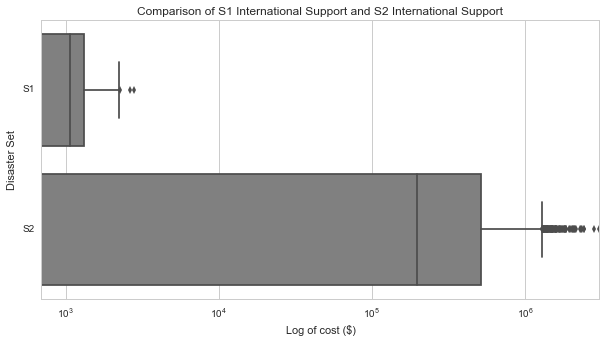

```python
returnBoxplot(S1['International support'], S2['International support'], 'limit')
```

As shown in the statistical summary, the difference between the mean of the International support for S1 and S2 are enormouse. A boxplot was drawn which showed that the range of the figure for the international support in S2 is also much greater than the International support in S1. The mean line between S1 and S2 boxplot are also very far apart. This shows that the units between the two datasets, in reference to International support, is not the same.

As indicated on EMDAT http://www.emdat.be/guidelines, the 'Aid contribution' is in 000'US$. Hence it could be that the International support for S2 had already been multiplied by 1000. This is to be reverted to see if it makes a difference.

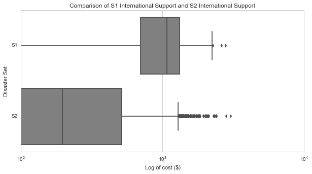

```python
S2['International support'] = S2['International support']/1000
returnBoxplot(S1['International support'], S2['International support'], 'none')
```

The boxplot now shows that both S1 and S2 International support are in similar range, as shown both minimum and maximum of both S1 and S2 are do not differ as much as before correcting the units.

#### Total affected and affected

There are evidence that total affected and affected are in fact by looking at the first few columns, upon further investigation it was found that they are in fact duplicate column, hence total affected will be remove.

```python
#determines length in which total affected is null and not equal to affected
len(S2[(S2['Total affected'] != S2['Affected']) & (S2['Total affected'].notnull())])
```

```
0
```

```python
del S2['Total affected']
```

#### S1 and S2 Affected

```python
S1.Affected.describe()
```

```
count    8.517000e+03
mean     4.535407e+05
std      5.962458e+06
min      1.000000e+00
25%      5.100000e+01
50%      7.950000e+02
75%      1.500000e+04
max      3.000000e+08
Name: Affected, dtype: float64
```

```python
S2.Affected.describe() * 1000
```

```
count    3.271000e+06
mean     3.897386e+05
std      5.979378e+06
min      1.000000e+03
25%      5.000000e+03
50%      1.600000e+04
75%      5.600000e+04
max      2.225700e+08
Name: Affected, dtype: float64
```

```python
S2.Affected = S2['Affected'] * 1000
```

## Merging Informations

In order to effectively intergrate S1 and S2, Semantic mapping is used to related the two schemas. Both name based matching and Instance based are used as a rule-based technique to exploit schema information. The name, data type and domain of the columns will be used to determine their equality.

#### Determining the mataching column of S1 and S2 through name-based matcher

First stage is to ensure that the column names convey the true semantics of the elements, hence the underscore will be removed from S1 and the semi colon will removed from S2. Also both column names will be in lowercase.

```python
S1.columns = S1.columns.str.replace('_', ' ') # removes underscores
S1.columns = S1.columns.str.lower()
S2.columns = S2.columns.str.lower()
```

```python
S1colname = []
S2colname = []
for i in S1.columns:
    for j in S2.columns:
        if (fuzz.partial_ratio(str(i), str(j))) > 80: #matching ratio is greater than 80
            S1colname.append(i) #appends to list
            S2colname.append(j)
similarities = pd.DataFrame({'S1 Column': S1colname, 'S2 Column': S2colname})
similarities
```

|  | S1 Column | S2 Column |
| --- | --- | --- |
| 0 | country | country iso |
| 1 | country | country name |
| 2 | type | disaster type |
| 3 | type | disaster subtype |
| 4 | sub type | disaster subtype |
| 5 | names | country name |
| 6 | affected | affected |
| 7 | international support | international support |

#### Changing S1 name in according to the result above

```python
S1.columns = ['start', 'end', 'country name', 'location', 'disaster type', 'disaster subtype', 'names', 'killed',
             'affected', 'international support']
```

```python
def semantic_mapping(S1, S2):
    S1colname = []
    S2colname = []
    for i in S1.columns:
        for j in S2.columns:
            if ((str(i) == str(j)) & (S1[str(i)].dtype == S2[str(j)].dtype)): #data type matchin, and column name match
                S1colname.append(i)
                S2colname.append(j)
    similarities = pd.DataFrame({'S1 Column': S1colname, 'S2 Column': S2colname}) #creates dataframe for matching pair
    return(similarities)
```

#### Checking all unmatched Start and End year

```python
dif = S1[S1.start.astype(str).str[0:4].astype(int) != S1.end.astype(str).str[0:4].astype(int)]
dif
```

|  | start | end | country name | location | disaster type | disaster subtype | names | killed | affected | international support |
| --- | --- | --- | --- | --- | --- | --- | --- | --- | --- | --- |
| 57 | 2005-12-01 | 2006-01-01 | Czech Republic | East | extreme temperature | extreme winter conditions | NaN | 15.0 | NaN | NaN |
| 65 | 2003-12-01 | 2004-01-01 | Philippines | Liloan:San Francisco:Ma ... | mass movement wet | landslide | NaN | 255.0 | 217988.0 | 558.926 |
| 97 | 1996-11-01 | 1997-01-01 | Burkina Faso | NaN | epidemic | bacterial infectious diseases | NaN | 64.0 | 461.0 | 1449.783 |
| 105 | 1998-12-01 | 1999-01-01 | Kenya | Nyanza:Eastern:Rift Val ... | epidemic | bacterial infectious diseases | Cholera | 27.0 | 1025.0 | 1197.933 |
| 142 | 2006-12-01 | 2007-02-01 | Somalia | Afgoi:Afmado:Balad:Bar ... | epidemic | viral infectious diseases | Rift Valley Fever | 51.0 | 63.0 | 1206.172 |
| 203 | 2008-09-01 | 2009-01-01 | Colombia | El Banco:Pedraza:Cerro ... | flood | general flood | NaN | 76.0 | 1200091.0 | 0.000 |
| 212 | 2008-09-01 | 2009-01-01 | Burundi | Kirundo:Ngozi:Muyinga: ... | drought | drought | NaN | NaN | 82500.0 | NaN |
| 213 | 2002-12-01 | 2003-05-01 | Congo | Mbomo:Kelle Ambomi:Ongo ... | epidemic | viral infectious diseases | Ebola | 128.0 | 15.0 | 720.861 |
| 241 | 2001-12-01 | 2002-01-01 | Malaysia | Pahang:Kelantan:Terengg ... | flood | general flood | NaN | 11.0 | 18000.0 | 564.659 |
| 266 | 1996-12-01 | 1997-01-01 | United States | Washington:Oregon:Nevad ... | flood | general flood | NaN | 28.0 | 18100.0 | 740.692 |
| 770 | 1998-12-01 | 1999-01-01 | Sri Lanka | Batticaloa:Trincomalee: ... | flood | general flood | NaN | 2.0 | 229485.0 | 965.784 |
| 975 | 1996-11-01 | 1997-06-01 | Somalia | Mogadishu:Merca:Middle ... | epidemic | bacterial infectious diseases | Cholera | 247.0 | 5557.0 | 1206.213 |
| 1113 | 2008-09-01 | 2009-06-01 | Zambia | Mpulungu district (Northe ... | epidemic | bacterial infectious diseases | Cholera | 173.0 | 8312.0 | 996.102 |
| 1170 | 1997-11-01 | 1998-04-01 | Cameroon | NaN | epidemic | NaN | Bloody diarrhoea | 60.0 | 237.0 | 1530.178 |
| 1229 | 2004-09-01 | 2005-01-01 | Congo | Kinshasa | epidemic | bacterial infectious diseases | Typhoid fever | 214.0 | 42564.0 | 943.393 |
| 1274 | 2008-12-01 | 2009-01-01 | Thailand | Phatthalung:Yala:Narath ... | flood | flash flood | NaN | NaN | 32584.0 | NaN |
| 1445 | 1990-12-01 | 1992-07-01 | Philippines | Regions VI:IX:X:XI and ... | drought | drought | NaN | NaN | 254282.0 | NaN |
| 1472 | 2005-12-01 | 2006-02-01 | Mozambique | Nampula:Sofala:Gaza:Za ... | flood | general flood | NaN | 16.0 | 29012.0 | 706.285 |
| 1657 | 1985-09-01 | 1986-03-01 | Bhutan | NaN | epidemic | bacterial infectious diseases | NaN | 41.0 | 247.0 | 1276.447 |
| 1824 | 1996-11-01 | 1997-04-01 | Togo | Dapaong:Savanes district ... | epidemic | bacterial infectious diseases | NaN | 360.0 | 2619.0 | 692.112 |
| 2207 | 1959-07-01 | 1961-07-01 | China | North | flood | NaN | NaN | 2000000.0 | NaN | NaN |
| 2440 | 2001-11-01 | 2002-03-01 | Congo | Kelle:Mbomo districts | epidemic | viral infectious diseases | Ebola | 19.0 | 13.0 | 720.857 |
| 2467 | 2005-12-01 | 2006-01-01 | Spain | North and North East and ... | extreme temperature | extreme winter conditions | NaN | 9.0 | NaN | NaN |
| 2675 | 2005-12-01 | 2006-01-01 | United States | Texas:Oklahoma | wildfire | forest fire | NaN | 5.0 | 1410.0 | 0.000 |
| 2709 | 1998-12-01 | 1999-04-01 | Somalia | Bay:Lower Shabelle:Uppe ... | epidemic | bacterial infectious diseases | Cholera | 233.0 | 7860.0 | 1206.227 |
| 2887 | 1997-10-01 | 1998-03-01 | Ecuador | Guayas and Los Rios:El O ... | flood | NaN | NaN | 218.0 | 35091.0 | 988.597 |
| 2997 | 2005-12-01 | 2006-01-01 | Bangladesh | Chittagong:Rajshahi:Jes ... | extreme temperature | extreme winter conditions | NaN | 100.0 | 1000.0 | 1191.521 |
| 3170 | 1984-01-01 | 1985-03-01 | Canada | Quebec:Prince Edouard Is ... | drought | drought | NaN | NaN | 30000.0 | NaN |
| 3545 | 2007-12-01 | 2008-01-01 | Timor-Leste | Aileu:Aiaro:Baucau:Bob ... | flood | NaN | NaN | NaN | NaN | NaN |
| 3633 | 1997-12-01 | 1998-03-01 | Peru | Cusco:Lima:Ica:Tumbes:... | storm | tropical cyclone | NaN | 518.0 | 580730.0 | 1715.430 |
| ... | ... | ... | ... | ... | ... | ... | ... | ... | ... | ... |
| 10318 | 2004-12-01 | 2005-03-01 | Brazil | Rio Grande do Sul:Paraïb ... | drought | drought | NaN | NaN | NaN | NaN |
| 10343 | 2007-12-01 | 2008-01-01 | Sri Lanka | Batticaloa:Ampara | flood | general flood | NaN | NaN | 250000.0 | NaN |
| 10680 | 1991-12-01 | 1992-01-01 | United States | Texas | flood | NaN | NaN | 15.0 | NaN | NaN |
| 10983 | 1997-12-01 | 1998-03-01 | Chad | Bokoro district:N'djamen ... | epidemic | bacterial infectious diseases | NaN | 239.0 | 2835.0 | 1365.655 |
| 11014 | 2004-10-01 | 2005-03-01 | Senegal | Pikine:Guédiawaye:Thiar ... | epidemic | bacterial infectious diseases | Cholera | 6.0 | 861.0 | 1319.676 |
| 11032 | 2000-08-01 | 2001-02-01 | Uganda | Gulu:Mbarara:Masindi di ... | epidemic | viral infectious diseases | Ebola haemorrhagic fever | 224.0 | 423.0 | 787.263 |
| 11094 | 2005-07-01 | 2006-03-01 | Somalia | Gov. Banadir (incl. Mogad ... | epidemic | viral infectious diseases | Poliomyelitis | NaN | 199.0 | NaN |
| 11131 | 1997-01-01 | 1998-12-01 | Kenya | Migori:Rachuonyo:Suba: ... | epidemic | bacterial infectious diseases | Cholera | 555.0 | 17200.0 | 1198.054 |
| 11220 | 2003-12-01 | 2004-01-01 | India | Uttar Pradesh:Himachal P ... | extreme temperature | cold wave | NaN | 400.0 | NaN | NaN |
| 11367 | 2002-09-01 | 2003-01-01 | Afghanistan | Aghram:Kuf sub-district:... | epidemic | bacterial infectious diseases | Pertusis | 17.0 | 115.0 | 852.568 |
| 11450 | 1983-02-01 | 1984-11-01 | Central African Republic | all coutry | drought | drought | NaN | NaN | NaN | NaN |
| 11531 | 2001-11-01 | 2002-03-01 | Congo | Katanga province | epidemic | bacterial infectious diseases | Cholera | 502.0 | 6099.0 | 943.174 |
| 11534 | 1999-11-01 | 2000-01-01 | Lesotho | Mohale's hoek district (s ... | epidemic | NaN | Dysentery | 28.0 | 1862.0 | 1626.897 |
| 11554 | 2008-12-01 | 2009-01-01 | Vietnam | Phu Yen:Binh Dinh:Quang ... | flood | general flood | NaN | 9.0 | 20000.0 | 1350.092 |
| 11579 | 2007-10-01 | 2008-10-01 | Mozambique | Tete:Mutarara district v ... | epidemic | bacterial infectious diseases | Cholera | 78.0 | 7547.0 | 996.272 |
| 11641 | 2005-12-01 | 2006-01-01 | Italy | NaN | extreme temperature | extreme winter conditions | NaN | 9.0 | NaN | NaN |
| 11809 | 2007-12-01 | 2008-02-01 | Zambia | Mazukaba:Siavonga:Maamb ... | flood | general flood | NaN | 1.0 | 34776.0 | 706.142 |
| 11817 | 2008-12-01 | 2009-01-01 | Mozambique | Maputo:Inhambe:Gaza pro ... | flood | general flood | NaN | 25.0 | 3500.0 | 706.124 |
| 11846 | 2008-12-01 | 2009-01-01 | Indonesia | West Lombok district (Wes ... | flood | general flood | NaN | 24.0 | 15000.0 | 1117.086 |
| 12107 | 2007-11-01 | 2008-01-01 | Malawi | Machinga:Ntcheu:Chiradz ... | flood | NaN | NaN | NaN | 2000.0 | NaN |
| 12121 | 2007-11-01 | 2009-01-01 | Uganda | Madi Opei (Lamwo County: ... | epidemic | viral infectious diseases | Hepatitis E Virus | 96.0 | 5761.0 | 787.292 |
| 12338 | 2008-05-01 | 2009-10-01 | Ethiopia | Oromia:Somali:Amhara:A ... | drought | drought | NaN | NaN | 6400000.0 | NaN |
| 12807 | 1999-08-01 | 2000-04-01 | Serbia | Pec:Djakovica region (Ko ... | epidemic | NaN | Tularemia | NaN | 699.0 | NaN |
| 12952 | 2008-11-01 | 2009-05-01 | Malawi | Blantyre:Lilongwe:Machi ... | epidemic | bacterial infectious diseases | Cholera | 113.0 | 5269.0 | 986.792 |
| 13006 | 2006-04-01 | 2007-02-01 | Ethiopia | Oromiya:Amhara:Somali: ... | epidemic | NaN | Acute Watery Diarrheal syndrome | 219.0 | 21882.0 | 946.444 |
| 13038 | 2006-11-01 | 2007-02-01 | North Korea | Kimhyongjik county (Ryang ... | epidemic | viral infectious diseases | NaN | 4.0 | 3000.0 | 718.182 |
| 13070 | 2005-10-01 | 2006-02-01 | Poland | NaN | extreme temperature | extreme winter conditions | NaN | 191.0 | NaN | NaN |
| 13190 | 2007-12-01 | 2008-01-01 | Mozambique | Buzi:Marromeu:Chemba:C ... | flood | NaN | NaN | 20.0 | 113535.0 | 706.818 |
| 13350 | 2006-11-01 | 2007-03-01 | Kenya | Garissa:Ijara:Wajir (No ... | epidemic | viral infectious diseases | Rift Valley Fever | 155.0 | 529.0 | 1197.934 |
| 13547 | 2002-07-01 | 2003-05-01 | Congo | Malemba Nkulu:Kabala:Bu ... | epidemic | bacterial infectious diseases | Cholera | 67.0 | 2636.0 | 943.136 |

154 rows × 10 columns

```python
len(dif)
```

```
154
```

#### Camping 'Los Alfaquez' - Incorrect date

```python
LosAlfaquez = S1[(S1['country name'] == 'Spain') & (S1.affected == 200.0)]
LosAlfaquez
```

|  | start | end | country name | location | disaster type | disaster subtype | names | killed | affected | international support |
| --- | --- | --- | --- | --- | --- | --- | --- | --- | --- | --- |
| 9811 | 1978-07-01 | 1987-07-01 | Spain | San Carlos Rapita (Costa ... | transport accident | road | Camping 'Los Alfaquez' | 216.0 | 200.0 | 1346.697 |

```python
S1.loc[9811, 'end'] = '1978-07-01' #replacing values
```

```python
len(S1[S1.start.astype(str).str[0:4].astype(int) != S1.end.astype(str).str[0:4].astype(int)])
```

```
153
```

```python
greatertwo = S1[(S1.end.astype(str).str[0:4].astype(int) - S1.start.astype(str).str[0:4].astype(int)) > 1]
greatertwo
```

|  | start | end | country name | location | disaster type | disaster subtype | names | killed | affected | international support |
| --- | --- | --- | --- | --- | --- | --- | --- | --- | --- | --- |
| 1445 | 1990-12-01 | 1992-07-01 | Philippines | Regions VI:IX:X:XI and ... | drought | drought | NaN | NaN | 254282.0 | NaN |
| 2207 | 1959-07-01 | 1961-07-01 | China | North | flood | NaN | NaN | 2000000.0 | NaN | NaN |
| 6695 | 2007-10-01 | 2009-02-01 | United States | California:Georgia:Mary ... | drought | drought | NaN | NaN | NaN | NaN |
| 10283 | 2005-01-01 | 2007-08-01 | Indonesia | Banten:Jakarta:West Jav ... | epidemic | viral infectious diseases | Avion Influenza H5N1 | 87.0 | 21.0 | 1407.114 |
| 12121 | 2007-11-01 | 2009-01-01 | Uganda | Madi Opei (Lamwo County: ... | epidemic | viral infectious diseases | Hepatitis E Virus | 96.0 | 5761.0 | 787.292 |

```python
set(greatertwo['disaster type'])
```

```
{'drought', 'epidemic', 'flood'}
```

#### Earthquake in Azerbaijan

```python
S2.loc[25] #finds corresponding row by index 25
```

```
year                                              2000
disaster type            earthquake (seismic activity)
country iso                                        AZE
country name                                Azerbaijan
disaster group                                 Natural
disaster subgroup                          Geophysical
disaster subtype           earthquake (ground shaking)
continent                                         Asia
region                                    Western Asia
occurence                                            1
total deaths                                        31
affected                                         31000
injured                                            600
homeless                                             0
total damage                                     10000
international support                          367.336
Name: 25, dtype: object
```

According to EMDAT, the Year in S2 most likely indicates when the disaster had occured, http://www.emdat.be/explanatory-notes. Also from the investigation above on S1, only 1.1% of disaster occured and ended in different year and the rest, 98.9% occured and ended in the same year. And most that occured are in fact the disaster that occured towards the end of the year and lasts a few months, extending to the following year. Only 5 rows of S1 contains Start Year and End Year that are more than 1 year apart, mostly to do with Drought, Epidemic and Flood.

Also upond investigation based on the information provided in row 25, Earthquake in Azerbaijan, occured in the year 2000, hence the year indicates the Year of the occurence of the disaster (Start Year). http://www.azer.com/aiweb/categories/magazine/84_folder/84_articles/84_earthquake.html

#### Adding Year Column to S1

```python
S1.insert(2, 'year', S1.start.astype(str).str[0:4]) #creates new column for Start Year
```

```python
S1.head(3)
```

|  | start | end | year | country name | location | disaster type | disaster subtype | names | killed | affected | international support |
| --- | --- | --- | --- | --- | --- | --- | --- | --- | --- | --- | --- |
| 0 | 1965-06-01 | 1965-06-01 | 1965 | Japan | NaN | storm | tropical cyclone | Dinah | 61.0 | 30000.0 | 1934.944 |
| 1 | 2004-09-01 | 2004-09-01 | 2004 | Grenada | NaN | storm | tropical cyclone | Ivan | 39.0 | 60000.0 | 1090.830 |
| 2 | 1995-03-01 | 1995-03-01 | 1995 | Russia | Kalmoukie:Daghestan (Mer ... | transport accident | water | NaN | 52.0 | NaN | NaN |

### Creating the global schema

```python
global_schema = pd.merge(S1, S2, how = 'outer') #merges by outer
```

```python
global_schema.head(3)
```

|  | start | end | year | country name | location | disaster type | disaster subtype | names | killed | affected | ... | country iso | disaster group | disaster subgroup | continent | region | occurence | total deaths | injured | homeless | total damage |
| --- | --- | --- | --- | --- | --- | --- | --- | --- | --- | --- | --- | --- | --- | --- | --- | --- | --- | --- | --- | --- | --- |
| 0 | 1965-06-01 | 1965-06-01 | 1965 | Japan | NaN | storm | tropical cyclone | Dinah | 61.0 | 30000.0 | ... | NaN | NaN | NaN | NaN | NaN | NaN | NaN | NaN | NaN | NaN |
| 1 | 2004-09-01 | 2004-09-01 | 2004 | Grenada | NaN | storm | tropical cyclone | Ivan | 39.0 | 60000.0 | ... | NaN | NaN | NaN | NaN | NaN | NaN | NaN | NaN | NaN | NaN |
| 2 | 1995-03-01 | 1995-03-01 | 1995 | Russia | Kalmoukie:Daghestan (Mer ... | transport accident | water | NaN | 52.0 | NaN | ... | NaN | NaN | NaN | NaN | NaN | NaN | NaN | NaN | NaN | NaN |

3 rows × 21 columns

```python
print 'Combined length of S1 and S2',len(S1) + len(S2), 'Length of the new global schema', len(global_schema)
```

```
Combined length of S1 and S2 18197 Length of the new global schema 18197
```

#### Global-as-View Approach for schema integration

Using this approach, the schema mapping will be applied to the global schema, where only the column that match between S1 and S2 would be used in the global schema. The semantic mapping rule consists of the attribute having the same domain, same attribute name and same data types

```python
similarities = semantic_mapping(S1, S2)
```

```python
for i in global_schema.columns:
    if i not in similarities['S1 Column'].to_string():
        del global_schema[str(i)] #remove all columns that did not match the similarities
```

```python
global_schema.head()
```

|  | year | country name | disaster type | disaster subtype | affected | international support |
| --- | --- | --- | --- | --- | --- | --- |
| 0 | 1965 | Japan | storm | tropical cyclone | 30000.0 | 1934.944 |
| 1 | 2004 | Grenada | storm | tropical cyclone | 60000.0 | 1090.830 |
| 2 | 1995 | Russia | transport accident | water | NaN | NaN |
| 3 | 1983 | Cuba | flood | NaN | 164575.0 | 905.275 |
| 4 | 1996 | Russia | industrial accident | gas leak | NaN | NaN |

#### Merging Region, ISO and Continent from S2 to globla_schema

As shown above, global schema Country and S2 Country are the same, and since S2 Country is related to the Region, Continent and ISO, S1 must also relate to them.

```python
S2Geo = S2[['continent', 'region', 'country iso', 'country name']]
global_schema = pd.merge(global_schema, S2Geo, on = 'country name', how="outer") #merges the geographical columns
global_schema.head(4)
```

|  | year | country name | disaster type | disaster subtype | affected | international support | continent | region | country iso |
| --- | --- | --- | --- | --- | --- | --- | --- | --- | --- |
| 0 | 1965 | Japan | storm | tropical cyclone | 30000.0 | 1934.944 | Asia | Eastern Asia | JPN |
| 1 | 1965 | Japan | storm | tropical cyclone | 30000.0 | 1934.944 | Asia | Eastern Asia | JPN |
| 2 | 1965 | Japan | storm | tropical cyclone | 30000.0 | 1934.944 | Asia | Eastern Asia | JPN |
| 3 | 1965 | Japan | storm | tropical cyclone | 30000.0 | 1934.944 | Asia | Eastern Asia | JPN |

```python
len(global_schema)
```

```
1065804
```

```python
print 'Number of duplicated rows', len(global_schema[global_schema.duplicated() == True])
```

```
Number of duplicated rows 1048698
```

#### Removing duplicates

There are 104,8698 worth of rows that are duplicates. This can be seen in the preview above that after merging the geographical attributes from S2, the country are repeated at least 66 times. These duplications will be removed to reduce the size of the dataset.

```python
global_schema.drop_duplicates(keep ='first',inplace = True) #removes duplicates
global_schema.reset_index(drop = True, inplace = True)
len(global_schema)
```

```
17106
```

```python
global_schema.head(3)
```

|  | year | country name | disaster type | disaster subtype | affected | international support | continent | region | country iso |
| --- | --- | --- | --- | --- | --- | --- | --- | --- | --- |
| 0 | 1965 | Japan | storm | tropical cyclone | 30000.0 | 1934.944 | Asia | Eastern Asia | JPN |
| 1 | 1992 | Japan | industrial accident | explosion | 8.0 | 1398.169 | Asia | Eastern Asia | JPN |
| 2 | 2001 | Japan | storm | tropical cyclone | 7040.0 | 1934.797 | Asia | Eastern Asia | JPN |

```python
print 'Number of duplicates ', len(global_schema[global_schema.duplicated() == True])
```

```
Number of duplicates  0
```

The duplicated rows were removed, this includes both from the duplicated country and duplicated rows in general.

#### Merging disease group and disease sub group from S2 to the global Schema

Since the disease type is reference to the disease group and subgroup, this information can also be merged into global schema.

```python
S2group = S2[['disaster group', 'disaster subgroup', 'disaster type']]
global_schema = pd.merge(global_schema, S2group, on = 'disaster type', how="outer")
global_schema.head(3)
```

|  | year | country name | disaster type | disaster subtype | affected | international support | continent | region | country iso | disaster group | disaster subgroup |
| --- | --- | --- | --- | --- | --- | --- | --- | --- | --- | --- | --- |
| 0 | 1965 | Japan | storm | tropical cyclone | 30000.0 | 1934.944 | Asia | Eastern Asia | JPN | Natural | Meteorological |
| 1 | 1965 | Japan | storm | tropical cyclone | 30000.0 | 1934.944 | Asia | Eastern Asia | JPN | Natural | Meteorological |
| 2 | 1965 | Japan | storm | tropical cyclone | 30000.0 | 1934.944 | Asia | Eastern Asia | JPN | Natural | Meteorological |

```python
print 'The number of rows of the new schema', len(global_schema)
```

```
The number of rows of the new schema 11796350
```

#### Removing duplicates

```python
global_schema.drop_duplicates(keep ='first',inplace = True) #drops duplicates
global_schema.reset_index(drop = True, inplace = True) #resets the index of the rows
```

```python
print 'Number of duplicated rows', len(global_schema)
```

```
Number of duplicated rows 17106
```

```python
global_schema.head(3)
```

|  | year | country name | disaster type | disaster subtype | affected | international support | continent | region | country iso | disaster group | disaster subgroup |
| --- | --- | --- | --- | --- | --- | --- | --- | --- | --- | --- | --- |
| 0 | 1965 | Japan | storm | tropical cyclone | 30000.0 | 1934.944 | Asia | Eastern Asia | JPN | Natural | Meteorological |
| 1 | 2001 | Japan | storm | tropical cyclone | 7040.0 | 1934.797 | Asia | Eastern Asia | JPN | Natural | Meteorological |
| 2 | 1960 | Japan | storm | tropical cyclone | NaN | NaN | Asia | Eastern Asia | JPN | Natural | Meteorological |

#### Rearranging the columns and sorting it by year

```python
global_schema = global_schema[['year', 'continent', 'region', 'country iso', 'country name', 'disaster group',
                         'disaster subgroup', 'disaster type', 'disaster subtype', 'affected', 'international support']]
```

```python
global_schema.year = global_schema.year.astype('str') #converts year to string
```

```python
global_schema = global_schema.sort_values(by = 'year') #sorts dataset by year
global_schema.head(3)
```

|  | year | continent | region | country iso | country name | disaster group | disaster subgroup | disaster type | disaster subtype | affected | international support |
| --- | --- | --- | --- | --- | --- | --- | --- | --- | --- | --- | --- |
| 1067 | 1900 | Americas | Northern America | USA | United States | Natural | Meteorological | storm | tropical cyclone | NaN | NaN |
| 15572 | 1900 | Americas | Caribbean | JAM | Jamaica | Natural | Biological | epidemic | viral infectious diseases | NaN | NaN |
| 5455 | 1900 | Americas | Northern America | USA | United States | NaN | NaN | miscellaneous accident | fire | NaN | NaN |

```python
print 'length of S1 and S2,', (len(S1) + len(S2)), ' and the length of the global schema, ', len(global_schema)
```

```
length of S1 and S2, 18197  and the length of the global schema,  17106
```

The combined number of rows from S1 and S2 produced 18,197 rows, however after merging some columns into the global schema and clearing the initial duplications, the figure is now at 17,106

#### Checking rows with more missing values than data

```python
#find all column that contains more than half the amount of missing value than the number of columns
fltnan = global_schema[global_schema.isnull().sum(axis=1) > len(global_schema.columns)/2]
fltnan
```

|  | year | continent | region | country iso | country name | disaster group | disaster subgroup | disaster type | disaster subtype | affected | international support |
| --- | --- | --- | --- | --- | --- | --- | --- | --- | --- | --- | --- |
| 6059 | 1970 | NaN | NaN | NaN | United Arab Emirates | NaN | NaN | miscellaneous accident | fire | NaN | NaN |
| 8965 | 1975 | NaN | NaN | NaN | Anguilla | NaN | NaN | transport accident | water | NaN | NaN |
| 13407 | 1983 | NaN | NaN | NaN | Anguilla | Natural | Hydrological | flood | NaN | NaN | NaN |
| 9025 | 1983 | NaN | NaN | NaN | United Arab Emirates | NaN | NaN | transport accident | air | NaN | NaN |
| 11147 | 1987 | NaN | NaN | NaN | Saint Kitts and Nevis | Natural | Hydrological | flood | NaN | NaN | NaN |
| 9004 | 1991 | NaN | NaN | NaN | Malta | NaN | NaN | transport accident | water | NaN | NaN |
| 4052 | 1993 | NaN | NaN | NaN | United Arab Emirates | NaN | NaN | industrial accident | fire | 100.0 | NaN |
| 9024 | 1999 | NaN | NaN | NaN | United Arab Emirates | NaN | NaN | transport accident | road | NaN | NaN |
| 9029 | 2000 | NaN | NaN | NaN | Bahrain | NaN | NaN | transport accident | air | NaN | NaN |
| 9000 | 2006 | NaN | NaN | NaN | Malta | NaN | NaN | transport accident | water | NaN | NaN |

As shown above there were 10 rows that contained more than 5 missing values.

#### Checking for disaster with the same type

Upon random searching of the dataset, it was discovered that as the day and month is not given, some of the rows could be redundant if the disaster type and disaster subtype were disregarded.

#### Guatemala

```python
global_schema[(global_schema.year == '1902') & (global_schema['country name'] == 'Guatemala')]
```

|  | year | continent | region | country iso | country name | disaster group | disaster subgroup | disaster type | disaster subtype | affected | international support |
| --- | --- | --- | --- | --- | --- | --- | --- | --- | --- | --- | --- |
| 9190 | 1902 | Americas | Central America | GTM | Guatemala | Natural | Geophysical | volcano | volcanic eruption | NaN | NaN |
| 4993 | 1902 | Americas | Central America | GTM | Guatemala | Natural | Geophysical | earthquake (seismic activity) | earthquake (ground shaking) | NaN | NaN |

#### Summary

There were no duplicates as it had previously been removed. However upon searching up certain disaster in 1902, Guatemala, it can be seen that Although the type of disaster is difference, earthquake most likely caused the eruption of the volcano. It might seem reasonable to keep either one of them, however they both represent two different types of disaster and could be based on different dates, consequently both will be kept.

### Duplication by Type

Some of the duplication occured where the Type of the disaster are the same, including international support and affected, however differs in the sub-type.

#### Creating a subset to identify the duplicates

```python
global_schema_sub = global_schema.copy()
del global_schema_sub['disaster subtype'] #removes disaster subtype from data
```

```python
fltr = global_schema_sub[global_schema_sub.duplicated() == True]
fltr = fltr[fltr.affected.notnull() & fltr['international support'].notnull()]
```

```python
fltr[fltr.duplicated(['international support']) | fltr.duplicated(['affected'])] # finds all column with either duplicates
```

|  | year | continent | region | country iso | country name | disaster group | disaster subgroup | disaster type | affected | international support |
| --- | --- | --- | --- | --- | --- | --- | --- | --- | --- | --- |
| 924 | 2001 | Americas | Northern America | USA | United States | Natural | Meteorological | storm | 100.0 | 1352.974 |
| 3597 | 2004 | Asia | Eastern Asia | CHN | China | NaN | NaN | industrial accident | 12.0 | 1371.608 |
| 8074 | 2006 | Africa | Eastern Africa | KEN | Kenya | NaN | NaN | transport accident | 3.0 | 910.302 |

#### United States

```python
global_schema[(global_schema.year == '2001') & (global_schema['country name'] == 'United States') & (global_schema.affected == 100.0)]
```

|  | year | continent | region | country iso | country name | disaster group | disaster subgroup | disaster type | disaster subtype | affected | international support |
| --- | --- | --- | --- | --- | --- | --- | --- | --- | --- | --- | --- |
| 999 | 2001 | Americas | Northern America | USA | United States | Natural | Meteorological | storm | NaN | 100.0 | 1352.974 |
| 924 | 2001 | Americas | Northern America | USA | United States | Natural | Meteorological | storm | local storm | 100.0 | 1352.974 |

#### China

```python
global_schema[(global_schema.year == '2004') & (global_schema['country name'] == 'China') & (global_schema.affected == 12.0)]
```

|  | year | continent | region | country iso | country name | disaster group | disaster subgroup | disaster type | disaster subtype | affected | international support |
| --- | --- | --- | --- | --- | --- | --- | --- | --- | --- | --- | --- |
| 3636 | 2004 | Asia | Eastern Asia | CHN | China | NaN | NaN | industrial accident | fire | 12.0 | 1371.608 |
| 3597 | 2004 | Asia | Eastern Asia | CHN | China | NaN | NaN | industrial accident | other | 12.0 | 1371.608 |

#### Kenya

```python
global_schema[(global_schema.year == '2006') & (global_schema['country name'] == 'Kenya') & (global_schema.affected == 3.0)]
```

|  | year | continent | region | country iso | country name | disaster group | disaster subgroup | disaster type | disaster subtype | affected | international support |
| --- | --- | --- | --- | --- | --- | --- | --- | --- | --- | --- | --- |
| 8089 | 2006 | Africa | Eastern Africa | KEN | Kenya | NaN | NaN | transport accident | road | 3.0 | 910.302 |
| 8074 | 2006 | Africa | Eastern Africa | KEN | Kenya | NaN | NaN | transport accident | air | 3.0 | 910.302 |

#### Removing duplicates

```python
global_schema = global_schema.drop(999) #drops row by index
global_schema = global_schema.drop(3597)
```

#### Summary:

As shown, there were 3 rows which was identified as duplicates, given that affected and international support is a real value. The duplicates relating to United States and China will be removed whereas in Kenya it will be kept as there could be both road and air transport accident.

### Cleaning final global schema

```python
global_schema.columns = global_schema.columns.str.title()
global_schema['Disaster Type'] = global_schema['Disaster Type'].str.title()
global_schema['Disaster Subtype'] = global_schema['Disaster Subtype'].str.title()
```

```python
global_schema.head(3)
```

|  | Year | Continent | Region | Country Iso | Country Name | Disaster Group | Disaster Subgroup | Disaster Type | Disaster Subtype | Affected | International Support |
| --- | --- | --- | --- | --- | --- | --- | --- | --- | --- | --- | --- |
| 1067 | 1900 | Americas | Northern America | USA | United States | Natural | Meteorological | Storm | Tropical Cyclone | NaN | NaN |
| 15572 | 1900 | Americas | Caribbean | JAM | Jamaica | Natural | Biological | Epidemic | Viral Infectious Diseases | NaN | NaN |
| 5455 | 1900 | Americas | Northern America | USA | United States | NaN | NaN | Miscellaneous Accident | Fire | NaN | NaN |

### Adding the Global Key

```python
global_schema.reset_index(level = 0, inplace = True)
global_schema['index'] = global_schema.index.astype('object')
global_schema['index'] = global_schema.index.map("{:02}".format) # Adds 1 zero if single digit
global_schema['index'] = global_schema.index.map("{:03}".format) # Adds 2 zero if single digit
#rips the year out, ISO and last 3 digits of the index and put that as the ID
global_schema.insert(0, 'ID', (global_schema.Year + '-' + global_schema['Country Iso'] + '-' + global_schema['index'].str[-3:]))
global_schema['ID'].fillna((global_schema.Year + '-' + global_schema['Country Name'].str[0:3].str.upper() + '-' + global_schema['index'].str[-3:]), inplace = True)
del global_schema['index']
```

```python
global_schema.head(3)
```

|  | ID | Year | Continent | Region | Country Iso | Country Name | Disaster Group | Disaster Subgroup | Disaster Type | Disaster Subtype | Affected | International Support |
| --- | --- | --- | --- | --- | --- | --- | --- | --- | --- | --- | --- | --- |
| 0 | 1900-USA-000 | 1900 | Americas | Northern America | USA | United States | Natural | Meteorological | Storm | Tropical Cyclone | NaN | NaN |
| 1 | 1900-JAM-001 | 1900 | Americas | Caribbean | JAM | Jamaica | Natural | Biological | Epidemic | Viral Infectious Diseases | NaN | NaN |
| 2 | 1900-USA-002 | 1900 | Americas | Northern America | USA | United States | NaN | NaN | Miscellaneous Accident | Fire | NaN | NaN |

```python
print 'There are', len(global_schema), 'records in the global schema and there are,', len(set(global_schema.ID)), 'ID'
```

```
There are 17104 records in the global schema and there are, 17104 ID
```

As shown the ID was produced based on the year of the disaster, the country ISO and a 3 digit value, and where the country ISO is missing, the first 3 capitalisesd letters of the country name was used instead of the ISO.

## Writing Global Schema to CSV

```python
global_schema.to_csv('27742377_data_integrated.csv') #writes global schema file to csv
```

## Mashup

#### Number of disasters betwen 1980-2015 for each countries

```python
import matplotlib.pyplot as plt
import matplotlib.cm
from mpl_toolkits.basemap import Basemap
from matplotlib.patches import Polygon
from matplotlib.collections import PatchCollection
from matplotlib.colors import Normalize
```

```python
S3 = global_schema.sample(frac = 0.8, random_state = 200) #shuffles the data and subsets 80%
print 'This is the original number of rows,', len(global_schema), 'and this is the number of rows with 80% of data,', len(S3)
```

```
This is the original number of rows, 17104 and this is the number of rows with 80% of data, 13683
```

#### Setting the country data

```python
S3 = S3[S3.Year.astype(int) > 1979] #filters the subseted data from the year 1980 and onwards
mash = pd.DataFrame(S3['Country Name'].value_counts()) #calculate the disaster occurence by country
mash.reset_index(level = 0, inplace = True) #takes out the country name index into a column
mash.columns = ['Country Name', 'Bin']
```

```python
mash = pd.merge(mash, global_schema[['Country Name', 'Country Iso']], how = 'inner', on = 'Country Name')
mash.drop_duplicates(keep ='first',inplace = True)
```

#### Drawing the map

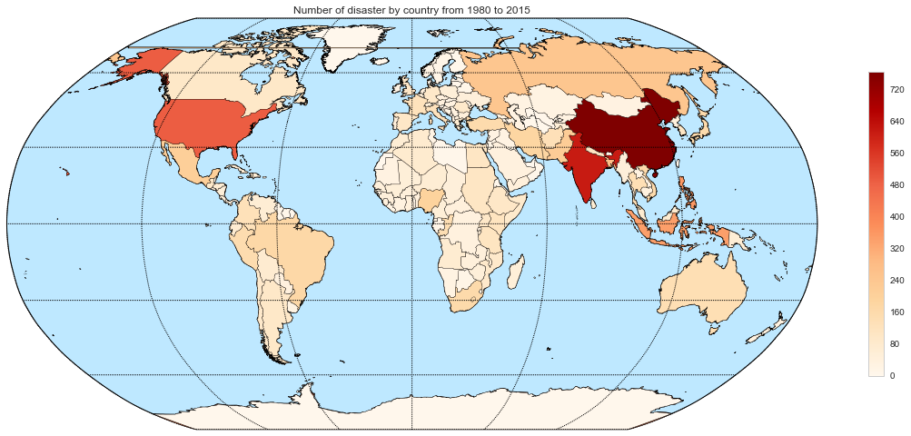

```python
#Inspired by http://maxberggren.se/2015/08/04/basemap/
#Inspired by http://brandonrose.org/pythonmap


#creating the map structure and color
fig, ax = plt.subplots(figsize = (20, 20))
m = Basemap(projection = 'robin', lon_0=0, llcrnrlat = -80,urcrnrlat = 80, llcrnrlon = -180,
            urcrnrlon = 180,lat_ts = 20, resolution='c') #creates properties of basemap, uses robinson map
m.drawmapboundary(fill_color = '#BEE8FF') #fills the ocean color
m.fillcontinents(color = 'coral', lake_color = '#FFF3E2') #fills lake color
m.drawparallels(np.arange(-90., 120, 30.)) #draws longitude lines
m.drawmeridians(np.arange(0., 360, 60.)) #draws latitude lines
m.drawcoastlines() #draw coast line

#title of the map
plt.title('Number of disaster by country from 1980 to 2015')

#extracting information of the shape of the map from shapefile
m.readshapefile('world_countries_boundary_file_world_2002', 'areas') #reads in the shape file
#extracts geographical information from the shapefiles
mash_poly = pd.DataFrame({'shapes': [Polygon(np.array(shape), True) for shape in m.areas],
                         'Country Iso': [iso['ISO_3_CODE'] for iso in m.areas_info]})

#assigning the color through the use of shadings
mash_poly = mash_poly.merge(mash, on = 'Country Iso', how = 'left')
colormap = plt.get_cmap('OrRd') #sets colour of the shading
patchcol = PatchCollection(mash_poly.shapes, zorder = 2)
norm = Normalize()
patchcol.set_facecolor(colormap(norm(mash_poly['Bin'].fillna(0).values)))
ax.add_collection(patchcol)

#setting side bar
barmapper = matplotlib.cm.ScalarMappable(norm = norm, cmap = colormap)
barmapper.set_array(mash_poly['Bin'])
plt.colorbar(barmapper, shrink = 0.3)
```